# SSC Case Study Exploratory Data Analysis

# Preamble

This is a supplementary notebook for the [2023 SSC Case Study](https://ssc.ca/en/case-study/understanding-how-canadas-economy-might-be-impacted-climate-change) to understand how Canada’s economy might be impacted by climate change. The zip files for the 3 provided data files ([Productivity](https://people.math.carleton.ca/~davecampbell/Case_Study_2023/geojson_files.zip), [Geographies](https://people.math.carleton.ca/~davecampbell/Case_Study_2023/geojson_files.zip), [Weather Data](https://people.math.carleton.ca/~davecampbell/Case_Study_2023/climate_data.zip)) are given along with background information on the case study.

Before running this notebook, please ensure that you have run the following chunk to acquire, curate, and clean the auxiliary data. The scripts are highly parallelized and intended for systems with multiple cores, as they will take several hours to run.

```r
# After Downloading the 3 Provided Datafiles from SSC Website...

# Acquire Climate Anomaly Data from ECCC
source("Climate Anomalies.R")

# Perform Spatial Interpolation of Climate Anomalies over Census GeoUID's
source("Climate Anomaly Interpolation.R")

# Perform Data Curation
source("Data Curation.R")
```

Load the relevant libraries and data from the correct directory.

```r
# Load Relevant Libraries
library(tidyverse)
library(lubridate)
library(sf)
library(geojsonsf)
library(terra)
library(trelliscopejs)
library(plotly)
```

# Productivity Data Overview

```r
productivity_data_full <- list.files('Productivity per NAICS within region/', full.names = T) %>%
  lapply(read_csv, show_col_types = FALSE) %>% bind_rows() %>%
  mutate(GeoUID = as.character(GeoUID)) %>%
  rename_with(~gsub("production_in_division_","", .x))

province_codings <- matrix(c(
"Newfoundland and Labrador", "NL",
"Prince Edward Island", "PE",
"Nova Scotia", "NS",
"New Brunswick", "NB",
"Quebec", "QC",
"Ontario", "ON",
"Manitoba", "MB",
"Saskatchewan", "SK",
"British Columbia", "BC",
"Alberta", "AB",
"Yukon", "YT",
"Northwest Territories", "NT",
"Nunavut", "NU"
),
ncol=2,byrow=TRUE,
dimnames = list(NULL, c("province", "abv"))) %>% as_tibble()
```

Productivity information is provided by [Dr. Dave Campbell](https://people.math.carleton.ca/~davecampbell/Case_Study_2023/Dataset-details.html):

> This (productivity data) comes from combining National Monthly GDP data with Provincial Annual GDP, measures of effort (provincial monthly total hours worked), and the census counts of people working in different industries in different geographic locations. All geographies are defined as Census Subdivisions with respect to the 2016 census GeoUIDs. Industries are classified according to the North American Industrial Classification System (NAICS). The dominant industry for the geography is defined in `Dominant_NAICS`. There is a single value per GeoUID. There is a hex colour code associated with industries and held in the column `colourval`.The variables relating to industry all contain 2 digit numbers. Those are the NAICS values that are encompassed. In many cases categories were combined, so multiple numbers are in one variable name. Despite the **production** variable name, they actually approximate the **productivity = output / effort** for a month within a census subdivision.

Please refer to this [GUIDE](https://www23.statcan.gc.ca/imdb/p3VD.pl?Function=getVD&TVD=1369825&CVD=1369826&CLV=0&MLV=5&D=1) for a detailed description on each industry.

```r
skimr::skim(productivity_data_full)
```

Data summary

| Name | productivity_data_full |
| --- | --- |
| Number of rows | 1516200 |
| Number of columns | 21 |
| _______________________ |  |
| Column type frequency: |  |
| character | 5 |
| Date | 1 |
| numeric | 15 |
| ________________________ |  |
| Group variables | None |

**Variable type: character**

| skim_variable | n_missing | complete_rate | min | max | empty | n_unique | whitespace |
| --- | --- | --- | --- | --- | --- | --- | --- |
| provincename | 0 | 1.00 | 6 | 25 | 0 | 10 | 0 |
| GeoUID | 0 | 1.00 | 7 | 7 | 0 | 5054 | 0 |
| census_year_ref | 0 | 1.00 | 4 | 4 | 0 | 1 | 0 |
| Dominant_NAICS | 173400 | 0.89 | 13 | 87 | 0 | 14 | 0 |
| colourval | 173400 | 0.89 | 7 | 7 | 0 | 14 | 0 |

**Variable type: Date**

| skim_variable | n_missing | complete_rate | min | max | median | n_unique |
| --- | --- | --- | --- | --- | --- | --- |
| Date | 0 | 1 | 1997-01-01 | 2021-12-01 | 2009-06-16 | 300 |

**Variable type: numeric**

| skim_variable | n_missing | complete_rate | mean | sd | p0 | p25 | p50 | p75 | p100 | hist |
| --- | --- | --- | --- | --- | --- | --- | --- | --- | --- | --- |
| X22.Utilities | 173400 | 0.89 | 8.41 | 55.28 | 0 | 0.00 | 0.00 | 3.44 | 2318.72 | ▇▁▁▁▁ |
| X23.Construction | 173400 | 0.89 | 25.92 | 201.10 | 0 | 1.02 | 2.91 | 9.49 | 11518.34 | ▇▁▁▁▁ |
| X31.33.Manufacturing | 173400 | 0.89 | 42.97 | 340.30 | 0 | 0.60 | 3.20 | 13.44 | 17013.52 | ▇▁▁▁▁ |
| X48.49.Transportation.and.warehousing | 173400 | 0.89 | 15.42 | 132.89 | 0 | 0.60 | 1.61 | 4.91 | 5935.07 | ▇▁▁▁▁ |
| X61.Educational.services | 173400 | 0.89 | 19.45 | 172.46 | 0 | 0.64 | 1.65 | 5.27 | 12589.36 | ▇▁▁▁▁ |
| X62.Health.care.and.social.assistance | 173400 | 0.89 | 25.67 | 204.96 | 0 | 0.83 | 2.47 | 8.12 | 10245.18 | ▇▁▁▁▁ |
| X72.Accommodation.and.food.services | 173400 | 0.89 | 7.74 | 69.76 | 0 | 0.21 | 0.55 | 1.97 | 3612.38 | ▇▁▁▁▁ |
| X81.Other.services..except.public.administration. | 173400 | 0.89 | 7.37 | 63.97 | 0 | 0.00 | 0.69 | 2.38 | 3392.00 | ▇▁▁▁▁ |
| X91.Public.administration | 173400 | 0.89 | 24.90 | 238.14 | 0 | 0.99 | 2.33 | 6.83 | 14853.66 | ▇▁▁▁▁ |
| X11.Agriculture.forestry.fishing.hunting.21.Mining.quarrying.and.oil.and.gas.extraction | 173400 | 0.89 | 35.51 | 294.53 | 0 | 2.66 | 7.79 | 23.39 | 24029.51 | ▇▁▁▁▁ |
| X41.Wholesale.trade.44.45.Retail.trade | 173400 | 0.89 | 36.20 | 305.78 | 0 | 0.82 | 2.66 | 9.56 | 16702.23 | ▇▁▁▁▁ |
| X52.Finance.and.insurance.53.Real.estate.and.rental.and.leasing | 173400 | 0.89 | 66.17 | 778.31 | 0 | 0.00 | 3.13 | 11.41 | 58526.46 | ▇▁▁▁▁ |
| X54.Professional..scientific.and.technical.services.55.56 | 173400 | 0.89 | 32.16 | 382.03 | 0 | 0.49 | 1.43 | 5.50 | 24089.95 | ▇▁▁▁▁ |
| X51.Information.culture.and.recreation.71 | 173400 | 0.89 | 14.58 | 171.54 | 0 | 0.00 | 0.82 | 2.82 | 11912.97 | ▇▁▁▁▁ |
| Population | 4200 | 1.00 | 6952.01 | 59940.22 | 0 | 222.00 | 695.50 | 2199.50 | 2731571.00 | ▇▁▁▁▁ |

The data ranges the 25 year span from 1997-01-01 to 2021-12-01 for the 10 provinces (territory data was unavailable). Each census subdivision has a unique `GeoUID`, with CSD types and their abbreviated forms found [HERE](https://www12.statcan.gc.ca/census-recensement/2021/ref/dict/tab/index-eng.cfm?ID=t1_5).

To re-frame the per-industry productivity in terms of their proportion of a subdivision’s economic composition, the raw values were converted to proportions of the total productivity at each time period. This allows for consistent comparisons to be made across time periods and provides insight into Canada’s changing economic landscape. The interactive plot below from `trelliscope` allows users to view each Region and its changing productivity proportions over time.

```r
geography_data_full <- list.files('geojson_files', full.names = T) %>%
  lapply(geojson_sf) %>%
  bind_rows() %>% mutate(GeoUID = as.numeric(GeoUID))

proportion_plot <- function(data) {
  (crosstalk::SharedData$new(data) %>% ggplot(aes( x = Date,
              y = productivity_proportion,
              color = industry,
              group = industry,
              text = sprintf("Industry: %s<br>Date: %s<br>Productivity Proportion: %s",
                             industry, format(Date,"%B %Y"),
                             scales::percent(100*productivity_proportion, scale = 1, accuracy = .01))

  )) +
    geom_line(show.legend = F) +
    theme_classic() + ylab("Proportion of Productivity") +
    theme(legend.position = "none") +
    theme(panel.grid.major = element_line(linetype = "dotted", colour = "black"))) %>%
  ggplotly(tooltip = "text") #%>% highlight(on = "plotly")
}

big_plot <- productivity_data_full %>%
  filter(!if_any(everything(), is.na),
    Date %within% interval("1997-01-01", "2017-12-01"),
         GeoUID %in% sample(GeoUID, 24)
         ) %>%
  mutate(
    total = rowSums(.[3:16]),
    across(c(3:16), ~.x/total)) %>%
  left_join(
    geography_data_full %>%
      mutate(GeoUID = as.character(GeoUID)) %>%
      st_drop_geometry() %>%
      select(GeoUID, Region.Name),
    by = "GeoUID"
  ) %>% mutate(
    URL = paste0("https://www12.statcan.gc.ca/census-recensement/2016/as-sa/fogs-spg/Facts-csd-eng.cfm?LANG=Eng&GK=CSD&GC=", GeoUID, "&TOPIC=1")
  ) %>%
  pivot_longer(cols = c(3:16), names_to = "industry",
               values_to = "productivity_proportion") %>%
  select(Region.Name, URL, provincename, industry, productivity_proportion, Date, Population) %>%
  rename(Region = Region.Name, Province = provincename) %>%
group_by(Region) %>%
  nest(data = c(industry, productivity_proportion, Date)) %>%
  #nest() %>%
  mutate(data_plot = map_plot(data, proportion_plot))

big_plot %>% ungroup %>% trelliscope(
  path = "./test1",
  #self_contained = TRUE,
  state = list(
    labels = c("Region", "Province", "URL")),
  name = "Productivity_Proportion",
  desc = "Economic Composition of Each Census Sub Division",
                                     nrow = 2, ncol = 2, width = 1000)
```

[interactive chart not shown]

# Geography Data Overview

The geography files are mutlipolygons that share `GeoUID`’s with the productivity data for plotting.

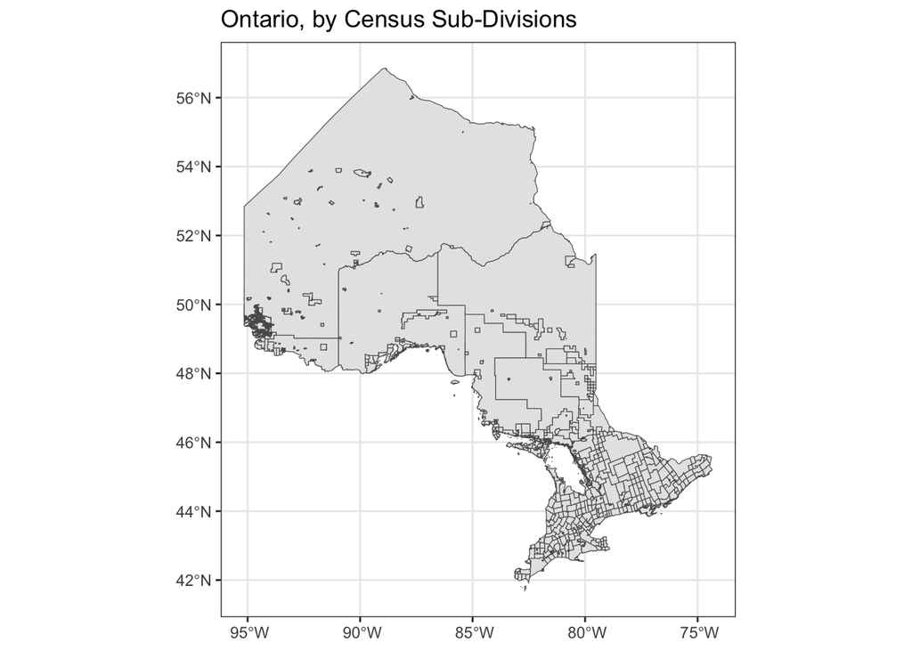

```r
geography_data_full %>% filter(provincename == "Ontario") %>%
  ggplot() +
  ggtitle("Ontario, by Census Sub-Divisions") +
  geom_sf() +
  theme_bw()
```

# Weather Data Overview

From Dr. Campbell:

> The weather data is directly taken from [Environment and Climate Change Canada](https://climate.weather.gc.ca/historical_data/search_historic_data_e.html) (ECCC). The climate variables are compiled monthly at weather stations. The variables include the geographic location, time variables, and a wide range of climate variables. Not all variables are measured at each weather station. The units are included in the weather variable names. Mean values (such as `Mean Max Temp (°C)`) are taken across all calendar dates. Extreme temperature values are taken across all the whole month (such as `Extr Min Temp (°C)` = the coldest minimum temperature recorded for the month). The full set of variable definitions are [also available](https://climate.weather.gc.ca/glossary_e.html)

```r
weather_data_full <- read_csv(
  "climate_data/weather_Station_data.csv",show_col_types = FALSE) %>%
  mutate(
    across(ends_with("Flag"),
           ~replace_na(.,"VALID") %>% str_replace("TRUE", "T") %>% as.factor),
    date_ym = make_date(year = as.numeric(Year), month = as.numeric(Month))
  ) %>% janitor::clean_names()

skimr::skim(weather_data_full)
```

Data summary

| Name | weather_data_full |
| --- | --- |
| Number of rows | 67710 |
| Number of columns | 30 |
| _______________________ |  |
| Column type frequency: |  |
| character | 4 |
| Date | 1 |
| factor | 11 |
| numeric | 14 |
| ________________________ |  |
| Group variables | None |

**Variable type: character**

| skim_variable | n_missing | complete_rate | min | max | empty | n_unique | whitespace |
| --- | --- | --- | --- | --- | --- | --- | --- |
| station_name | 0 | 1 | 3 | 30 | 0 | 547 | 0 |
| climate_id | 0 | 1 | 3 | 9 | 0 | 552 | 0 |
| date_time | 0 | 1 | 7 | 7 | 0 | 242 | 0 |
| month | 0 | 1 | 2 | 2 | 0 | 12 | 0 |

**Variable type: Date**

| skim_variable | n_missing | complete_rate | min | max | median | n_unique |
| --- | --- | --- | --- | --- | --- | --- |
| date_ym | 0 | 1 | 1998-01-01 | 2018-02-01 | 2003-11-01 | 242 |

**Variable type: factor**

| skim_variable | n_missing | complete_rate | ordered | n_unique | top_counts |
| --- | --- | --- | --- | --- | --- |
| mean_max_temp_flag | 0 | 1 | FALSE | 3 | VAL: 50563, E: 13338, I: 3809 |
| mean_min_temp_flag | 0 | 1 | FALSE | 4 | VAL: 50772, E: 13060, I: 3859, M: 19 |
| mean_temp_flag | 0 | 1 | FALSE | 4 | VAL: 47344, E: 14969, I: 5396, M: 1 |
| extr_max_temp_flag | 0 | 1 | FALSE | 5 | VAL: 51671, E: 6123, S: 5121, I: 3809 |
| extr_min_temp_flag | 0 | 1 | FALSE | 6 | VAL: 50843, E: 6017, S: 5903, I: 3855 |
| total_rain_flag | 0 | 1 | FALSE | 5 | VAL: 57050, I: 6830, E: 2776, T: 890 |
| total_snow_flag | 0 | 1 | FALSE | 5 | VAL: 58132, I: 4314, E: 3277, T: 1865 |
| total_precip_flag | 0 | 1 | FALSE | 5 | VAL: 53869, I: 9268, E: 4502, T: 49 |
| snow_grnd_last_day_flag | 0 | 1 | FALSE | 4 | VAL: 64191, M: 2448, T: 889, E: 182 |
| dir_of_max_gust_flag | 0 | 1 | FALSE | 6 | VAL: 66133, E: 1037, I: 236, M: 141 |
| spd_of_max_gust_flag | 0 | 1 | FALSE | 6 | VAL: 66134, E: 1037, I: 236, M: 139 |

**Variable type: numeric**

| skim_variable | n_missing | complete_rate | mean | sd | p0 | p25 | p50 | p75 | p100 | hist |
| --- | --- | --- | --- | --- | --- | --- | --- | --- | --- | --- |
| longitude_x | 0 | 1.00 | -95.58 | 22.78 | -140.85 | -117.31 | -98.88 | -73.13 | -52.94 | ▃▆▃▇▂ |
| latitude_y | 0 | 1.00 | 49.86 | 5.44 | 42.04 | 46.07 | 49.18 | 51.27 | 82.50 | ▇▃▁▁▁ |
| year | 0 | 1.00 | 2004.02 | 4.66 | 1998.00 | 2000.00 | 2003.00 | 2006.00 | 2018.00 | ▇▇▂▁▁ |
| mean_max_temp_c | 6394 | 0.91 | 9.98 | 11.46 | -36.10 | 1.20 | 10.80 | 19.90 | 34.00 | ▁▁▆▇▅ |
| mean_min_temp_c | 6411 | 0.91 | -0.24 | 10.65 | -43.40 | -7.80 | 1.60 | 8.40 | 20.70 | ▁▁▅▇▅ |
| mean_temp_c | 6522 | 0.90 | 4.88 | 10.96 | -39.60 | -3.30 | 6.10 | 14.10 | 25.90 | ▁▁▆▇▆ |
| extr_max_temp_c | 6394 | 0.91 | 19.18 | 10.67 | -29.10 | 10.50 | 20.50 | 28.50 | 42.80 | ▁▁▇▇▆ |
| extr_min_temp_c | 6411 | 0.91 | -9.20 | 13.78 | -52.30 | -20.00 | -5.00 | 1.70 | 17.10 | ▁▃▃▇▃ |
| total_rain_mm | 14215 | 0.79 | 65.69 | 79.05 | 0.00 | 11.40 | 46.00 | 92.60 | 997.90 | ▇▁▁▁▁ |
| total_snow_cm | 14151 | 0.79 | 13.80 | 25.66 | 0.00 | 0.00 | 0.00 | 18.00 | 462.70 | ▇▁▁▁▁ |
| total_precip_mm | 7566 | 0.89 | 79.11 | 77.75 | 0.00 | 29.60 | 62.50 | 103.00 | 997.90 | ▇▁▁▁▁ |
| snow_grnd_last_day_cm | 17793 | 0.74 | 7.53 | 22.52 | 0.00 | 0.00 | 0.00 | 0.00 | 955.00 | ▇▁▁▁▁ |
| dir_of_max_gust_10s_deg | 66002 | 0.03 | 22.93 | 8.48 | 0.00 | 15.00 | 25.00 | 29.00 | 36.00 | ▂▃▃▇▇ |
| spd_of_max_gust_km_h | 66000 | 0.03 | 66.48 | 14.45 | 32.00 | 56.00 | 65.00 | 74.00 | 154.00 | ▃▇▂▁▁ |

The flag definitions are given below.

```r
weathercan::flags
```

| code | meaning |
| --- | --- |
| [empty] | Indicates an unobserved value |
| † | Data that is not subject to review by the National Climate Archives |
| ^ | The value displayed is based on incomplete data |
| A | Accumulated |
| B | More than one occurrence and estimated |
| C | Precipitation occurred, amount uncertain |
| E | Estimated |
| F | Accumulated and estimated |
| L | Precipitation may or may not have occurred |
| M | Missing |

[output cut: 5 more lines]

# Data Preparation

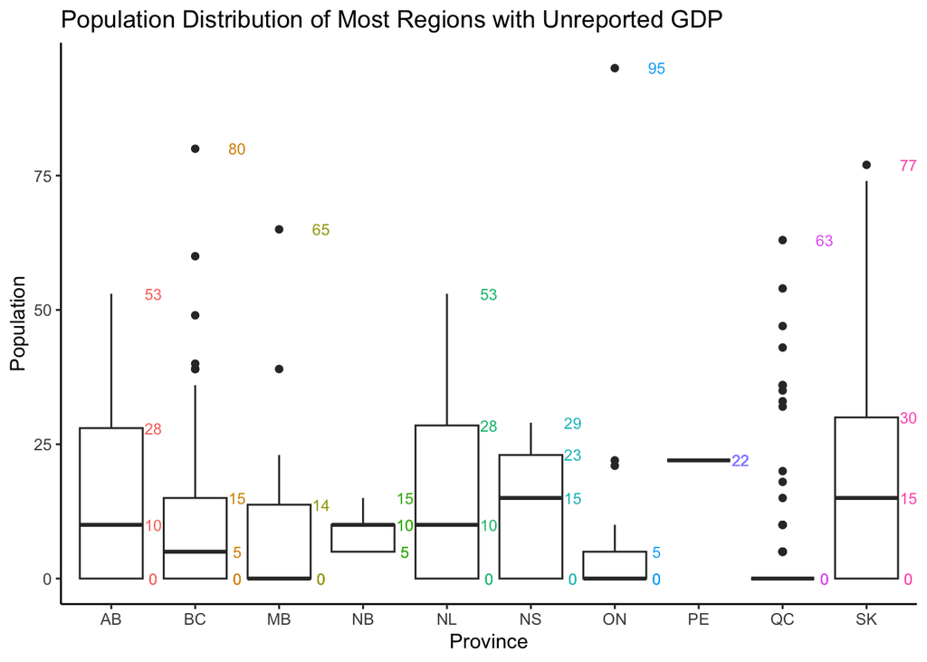

```r
#, fig.width=5, fig.height=6}

productivity_data_full %>%
filter(if_any(dplyr::everything(), is.na), Population < 100) %>%
    left_join(province_codings, by = c("provincename" = "province")) %>%
  distinct(GeoUID, .keep_all = T) %>%
ggplot(aes(x = abv, y = Population)) + geom_boxplot() +
stat_summary(geom = "text", fun = quantile,
aes(label = sprintf("%1.0f", after_stat(y)),
color = abv), show.legend = F,
position = position_nudge(x = 0.5), size = 3) +
  #ggbreak::scale_y_break( breaks = c(155,315)) +
xlab("Province") +
ggtitle("Population Distribution of Most Regions with Unreported GDP" )+
theme_classic()
```

Therefore, we filtered out all datapoints with missing values or zeroes across the row, and were left with 4468 out of the 5054 original GeoUIDs. Due to how the data was prepared, the productivity values for these 4468 remaining census subdivisions were perfectly balanced panel data.

The weather data was not so friendly, with a plethora of missing values and inconsistent readings across stations. For example, not all stations tracked the same measurements, and others were only in operation for a subset of total time range. This is partially due to the uneven dispersion of weather stations across the country, with several stations location within a small geographical area like the GTA, and only **four** in the entire province of Prince Edward Island, shown below.

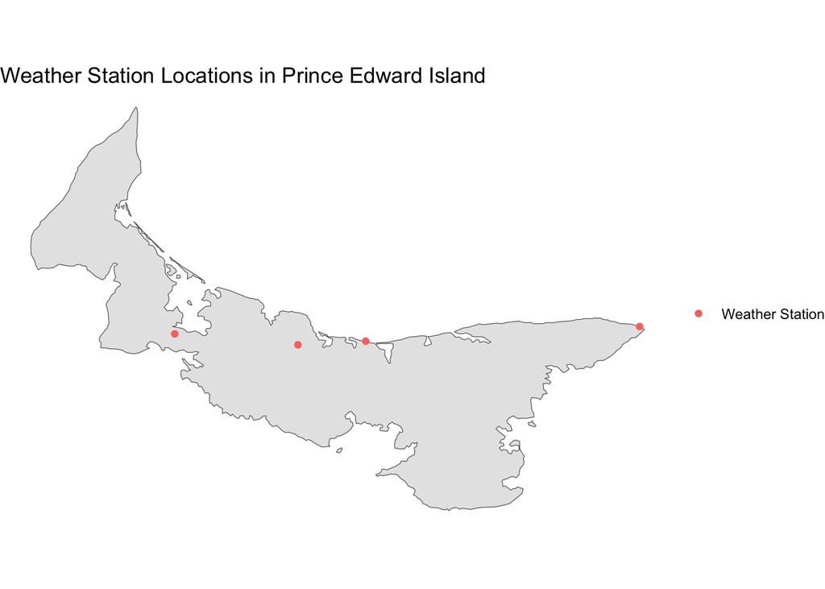

```r
canadianmaps::PROV %>% filter(PT == "PE") %>% ggplot() +
  geom_sf() +
  geom_point(aes(x = longitude_x, y = latitude_y, color = "Weather Station"),
             data = weather_data_full %>%
            filter(date_time == "2005-01",
                   dplyr::between(longitude_x, -64, -61),
                   dplyr::between(latitude_y, 46, 47))
  ) +
  ggtitle("Weather Station Locations in Prince Edward Island") +
  labs(color = NULL) +
  theme_void()
```

To combat this problem, we augmented the existing data with measurements from [more stations](https://docs.ropensci.org/weathercan/index.html) and added [carbon dioxide concentrations](https://www.canada.ca/en/environment-climate-change/services/environmental-indicators/greenhouse-gas-concentrations.html). We also decided to work with **climate anomalies** instead of absolute climate measurements since they are [significantly easier to accurately estimate](https://data.giss.nasa.gov/gistemp/faq/abs_temp.html) in data sparse areas. The reference (normals) year for the anomaly calculation was 1971-2000. Finally, we used the Inverse Distance Weighted (IDW) spatial interpolation method to estimate climate anomalies across the country and aggregated them over the geographic multi-polygons that comprised each census subdivision. IDW satisfies Tobler’s first law of geography and estimates the value of a location in space as an inversely weighted average of its neighboring points.

# Climate Anomaly Data Overview

The following table gives an overview of the climate anomaly data. Please ensure that the scripts `Climate Anomalies.R`, `Climate Anomaly Interpolation.R`, and `Data Curation.R` have been run in order.

```r
full_data <- read_csv("full_data.csv", show_col_types = F)
skimr::skim(full_data %>% select(ends_with("anomaly")))
```

Data summary

| Name | full_data %>% select(ends… |
| --- | --- |
| Number of rows | 1125936 |
| Number of columns | 10 |
| _______________________ |  |
| Column type frequency: |  |
| numeric | 10 |
| ________________________ |  |
| Group variables | None |

**Variable type: numeric**

| skim_variable | n_missing | complete_rate | mean | sd | p0 | p25 | p50 | p75 | p100 | hist |
| --- | --- | --- | --- | --- | --- | --- | --- | --- | --- | --- |
| mean_max_temp_anomaly | 0 | 1 | 0.76 | 2.12 | -14.81 | -0.46 | 0.72 | 2.02 | 13.90 | ▁▁▇▂▁ |
| mean_min_temp_anomaly | 0 | 1 | 0.85 | 2.16 | -14.59 | -0.26 | 0.77 | 1.88 | 14.85 | ▁▁▇▁▁ |
| mean_temp_anomaly | 0 | 1 | 0.81 | 2.07 | -11.65 | -0.30 | 0.75 | 1.92 | 12.85 | ▁▁▇▁▁ |
| extr_max_temp_anomaly | 0 | 1 | -5.91 | 3.05 | -38.03 | -7.71 | -5.60 | -3.78 | 8.22 | ▁▁▁▇▁ |
| extr_min_temp_anomaly | 0 | 1 | 8.80 | 4.59 | -10.98 | 5.44 | 7.57 | 11.53 | 39.29 | ▁▇▅▁▁ |
| total_precip_anomaly | 0 | 1 | -1.28 | 28.81 | -334.23 | -17.09 | -3.65 | 11.67 | 514.70 | ▁▇▅▁▁ |
| total_rain_anomaly | 0 | 1 | 0.08 | 27.24 | -332.53 | -13.51 | -1.56 | 10.40 | 509.09 | ▁▇▅▁▁ |
| total_snow_anomaly | 0 | 1 | -0.88 | 11.51 | -115.27 | -4.00 | -0.04 | 0.10 | 170.19 | ▁▅▇▁▁ |
| snow_grnd_last_day_anomaly | 0 | 1 | 0.16 | 8.41 | -115.88 | -0.92 | 0.00 | 0.00 | 186.24 | ▁▇▁▁▁ |
| co2_anomaly | 0 | 1 | 33.33 | 13.90 | 2.91 | 22.11 | 32.96 | 44.18 | 61.01 | ▂▇▇▇▅ |

The **positive** mean values for the minimum, maximum, and average temperature show that average temperature is on the rise in Canada, and the **wide range** of the extreme anomalies echo concerns about increasing volatility in weather.

```r
anomaly_data_long <- full_data %>%
  left_join(
    geography_data_full %>%
      st_drop_geometry() %>%
      select(GeoUID, Region.Name) %>%
      rename(Region = Region.Name),
    by = "GeoUID"
  ) %>%
  select(Date, provincename, GeoUID, Region, ends_with("anomaly")) %>% mutate(year = year(Date)) %>% pivot_longer(cols = ends_with("anomaly"), names_to = "variable",
values_to = "measurement")
```

To get a better idea of the long term trajectory of climate change in Canada and better understand which regions are facing the fastest changing climate, we performed a seasonal trend decomposition of each climate anomaly and isolated the trend component, with summary statistics provided from the “filter” column of the interactive plot:

```r
climate_time_series <- function(data) {
  ts1 <- ts(data$measurement, frequency = 12,
            start = c(year(min(data$Date)),month(min(data$Date)))) %>%
    decompose("additive")
}

climate_trend_plot <- function(data) (
  data$trend %>% forecast::autoplot() +
    stat_smooth(method = "loess", formula = y~x, show.legend = F) +
    theme_bw() )

d <- anomaly_data_long %>%
  filter(variable != "co2_anomaly") %>%
  select(provincename, Region, variable, Date, measurement) %>%
  rename(Province = provincename) %>%
group_by(Province, variable, Date) %>%
summarise(measurement = mean(measurement)) %>%
  nest() %>%
  mutate(model = map(data, climate_time_series),
         panel = map_plot(model, climate_trend_plot)) %>% autocogs::add_panel_cogs() %>%
  select(-c(data, model, `_x`))

d %>% ungroup() %>% trelliscope(name = "Anomaly_Trends", nrow = 2, ncol = 2,
                  width = 1000,
              panel_col = "panel",
              state = list(
                sort = list(sort_spec("correlation")),
                labels = c("Province", "variable", "correlation", "var")
              ),
              desc = "Climate Anomaly Trends For Every Canadian Province",
              #self_contained = T,
              path = "./test2")
```

[interactive chart not shown]